# CNN_cfs4_big

### already trained small model in CNN_cfs4.ipynb using X1 so now use X2 then using X12

```python
model_sm1=construct_new_small_cfs_model(15)
```

[output not shown]

```python
batch_size = 32
epochs = 100
# Define checkpoint callback
checkpoint = ModelCheckpoint('cfs4_small_model_X1.h5', monitor='val_loss', save_best_only=True, mode='min', verbose=1)
# opt = keras.optimizers.Adam(learning_rate=0.01) # not using this atm
model_sm1.compile(loss="mse", optimizer="adam", metrics=[MeanSquaredError(),MeanAbsoluteError()])
```

```python
history_sm1 =model_sm1.fit(X_train1,y_train1,batch_size=batch_size, epochs=epochs, validation_split=0.2,callbacks=[checkpoint])
```

```
Epoch 1: val_loss improved from inf to 0.24077, saving model to cfs4_small_model_X1.h5
Epoch 2: val_loss did not improve from 0.24077
Epoch 3: val_loss did not improve from 0.24077
Epoch 4: val_loss did not improve from 0.24077
Epoch 5: val_loss did not improve from 0.24077
Epoch 6: val_loss did not improve from 0.24077
Epoch 7: val_loss improved from 0.24077 to 0.22212, saving model to cfs4_small_model_X1.h5
Epoch 8: val_loss improved from 0.22212 to 0.16935, saving model to cfs4_small_model_X1.h5
Epoch 9: val_loss improved from 0.16935 to 0.15249, saving model to cfs4_small_model_X1.h5
Epoch 10: val_loss improved from 0.15249 to 0.11806, saving model to cfs4_small_model_X1.h5
Epoch 11: val_loss improved from 0.11806 to 0.09251, saving model to cfs4_small_model_X1.h5
Epoch 12: val_loss improved from 0.09251 to 0.08069, saving model to cfs4_small_model_X1.h5
Epoch 13: val_loss improved from 0.08069 to 0.06803, saving model to cfs4_small_model_X1.h5
Epoch 14: val_loss improved from 0.06803 to 0.05721, saving model to cfs4_small_model_X1.h5
Epoch 15: val_loss improved from 0.05721 to 0.03693, saving model to cfs4_small_model_X1.h5
Epoch 16: val_loss improved from 0.03693 to 0.03452, saving model to cfs4_small_model_X1.h5
Epoch 17: val_loss improved from 0.03452 to 0.03225, saving model to cfs4_small_model_X1.h5
Epoch 18: val_loss improved from 0.03225 to 0.02695, saving model to cfs4_small_model_X1.h5
Epoch 19: val_loss improved from 0.02695 to 0.02396, saving model to cfs4_small_model_X1.h5
Epoch 20: val_loss improved from 0.02396 to 0.02165, saving model to cfs4_small_model_X1.h5
Epoch 21: val_loss improved from 0.02165 to 0.02095, saving model to cfs4_small_model_X1.h5
Epoch 22: val_loss improved from 0.02095 to 0.01882, saving model to cfs4_small_model_X1.h5
Epoch 23: val_loss improved from 0.01882 to 0.01746, saving model to cfs4_small_model_X1.h5
Epoch 24: val_loss improved from 0.01746 to 0.01473, saving model to cfs4_small_model_X1.h5
Epoch 25: val_loss improved from 0.01473 to 0.01196, saving model to cfs4_small_model_X1.h5
Epoch 26: val_loss did not improve from 0.01196
Epoch 27: val_loss did not improve from 0.01196
Epoch 28: val_loss improved from 0.01196 to 0.01156, saving model to cfs4_small_model_X1.h5
Epoch 29: val_loss improved from 0.01156 to 0.00907, saving model to cfs4_small_model_X1.h5
Epoch 30: val_loss did not improve from 0.00907
Epoch 31: val_loss did not improve from 0.00907
Epoch 32: val_loss improved from 0.00907 to 0.00874, saving model to cfs4_small_model_X1.h5
Epoch 33: val_loss improved from 0.00874 to 0.00794, saving model to cfs4_small_model_X1.h5
Epoch 34: val_loss improved from 0.00794 to 0.00788, saving model to cfs4_small_model_X1.h5
Epoch 35: val_loss improved from 0.00788 to 0.00765, saving model to cfs4_small_model_X1.h5
Epoch 36: val_loss improved from 0.00765 to 0.00709, saving model to cfs4_small_model_X1.h5
Epoch 37: val_loss did not improve from 0.00709
Epoch 38: val_loss did not improve from 0.00709
Epoch 39: val_loss did not improve from 0.00709
Epoch 40: val_loss did not improve from 0.00709
```

[output cut: 45 more lines]

```
Epoch 86: val_loss did not improve from 0.00251
Epoch 87: val_loss improved from 0.00251 to 0.00248, saving model to cfs4_small_model_X1.h5
Epoch 88: val_loss improved from 0.00248 to 0.00247, saving model to cfs4_small_model_X1.h5
Epoch 89: val_loss improved from 0.00247 to 0.00246, saving model to cfs4_small_model_X1.h5
Epoch 90: val_loss did not improve from 0.00246
Epoch 91: val_loss did not improve from 0.00246
Epoch 92: val_loss improved from 0.00246 to 0.00245, saving model to cfs4_small_model_X1.h5
Epoch 93: val_loss did not improve from 0.00245
Epoch 94: val_loss improved from 0.00245 to 0.00238, saving model to cfs4_small_model_X1.h5
Epoch 95: val_loss did not improve from 0.00238
Epoch 96: val_loss did not improve from 0.00238
Epoch 97: val_loss did not improve from 0.00238
Epoch 98: val_loss did not improve from 0.00238
Epoch 99: val_loss did not improve from 0.00238
Epoch 100: val_loss did not improve from 0.00238
```

```python
model_sm1.name
```

```
'seq_CNN_sm'
```

```
Loss: 0.0024392143823206425
Mean Square Error: 0.0024392143823206425
Mean Absolute Error: 0.037766385823488235
Test R2 score: 0.9734401726481011
```

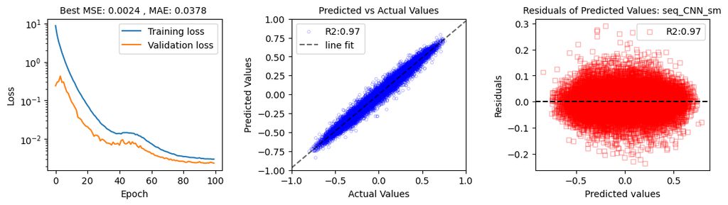

```python
model_evaluate_and_plot(model_sm1,history_sm1,X_test1,y_test1)
```

```python
model_sm2=construct_new_small_cfs_model(15)

batch_size = 32
epochs = 100
# Define checkpoint callback
checkpoint = ModelCheckpoint('cfs4_small_model_X2.h5', monitor='val_loss', save_best_only=True, mode='min', verbose=1)
# opt = keras.optimizers.Adam(learning_rate=0.01) # not using this atm
model_sm2.compile(loss="mse", optimizer="adam", metrics=[MeanSquaredError(),MeanAbsoluteError()])
```

# Load the saved weights into the model # model.load_weights('cfs4_small_model_X2.h5')

```python
history_sm2 =model_sm2.fit(X_train2,y_train2,batch_size=batch_size, epochs=epochs, validation_split=0.2,callbacks=[checkpoint])

# ## Evaluate the trained model

# In[ ]:
```

```
Epoch 1: val_loss improved from inf to 0.29960, saving model to cfs4_small_model_X2.h5
Epoch 2: val_loss did not improve from 0.29960
Epoch 3: val_loss did not improve from 0.29960
Epoch 4: val_loss did not improve from 0.29960
Epoch 5: val_loss did not improve from 0.29960
Epoch 6: val_loss improved from 0.29960 to 0.29936, saving model to cfs4_small_model_X2.h5
Epoch 7: val_loss improved from 0.29936 to 0.28355, saving model to cfs4_small_model_X2.h5
Epoch 8: val_loss improved from 0.28355 to 0.21052, saving model to cfs4_small_model_X2.h5
Epoch 9: val_loss improved from 0.21052 to 0.16810, saving model to cfs4_small_model_X2.h5
Epoch 10: val_loss improved from 0.16810 to 0.14101, saving model to cfs4_small_model_X2.h5
Epoch 11: val_loss improved from 0.14101 to 0.11018, saving model to cfs4_small_model_X2.h5
Epoch 12: val_loss improved from 0.11018 to 0.07733, saving model to cfs4_small_model_X2.h5
Epoch 13: val_loss improved from 0.07733 to 0.06858, saving model to cfs4_small_model_X2.h5
Epoch 14: val_loss did not improve from 0.06858
Epoch 15: val_loss improved from 0.06858 to 0.06083, saving model to cfs4_small_model_X2.h5
Epoch 16: val_loss improved from 0.06083 to 0.05424, saving model to cfs4_small_model_X2.h5
Epoch 17: val_loss improved from 0.05424 to 0.04983, saving model to cfs4_small_model_X2.h5
Epoch 18: val_loss improved from 0.04983 to 0.04138, saving model to cfs4_small_model_X2.h5
Epoch 19: val_loss improved from 0.04138 to 0.03720, saving model to cfs4_small_model_X2.h5
Epoch 20: val_loss did not improve from 0.03720
Epoch 21: val_loss improved from 0.03720 to 0.03630, saving model to cfs4_small_model_X2.h5
Epoch 22: val_loss did not improve from 0.03630
Epoch 23: val_loss improved from 0.03630 to 0.03400, saving model to cfs4_small_model_X2.h5
Epoch 24: val_loss did not improve from 0.03400
Epoch 25: val_loss improved from 0.03400 to 0.03238, saving model to cfs4_small_model_X2.h5
Epoch 26: val_loss improved from 0.03238 to 0.03194, saving model to cfs4_small_model_X2.h5
Epoch 27: val_loss improved from 0.03194 to 0.03064, saving model to cfs4_small_model_X2.h5
Epoch 28: val_loss improved from 0.03064 to 0.02873, saving model to cfs4_small_model_X2.h5
Epoch 29: val_loss did not improve from 0.02873
Epoch 30: val_loss improved from 0.02873 to 0.02648, saving model to cfs4_small_model_X2.h5
Epoch 31: val_loss did not improve from 0.02648
Epoch 32: val_loss did not improve from 0.02648
Epoch 33: val_loss did not improve from 0.02648
Epoch 34: val_loss did not improve from 0.02648
Epoch 35: val_loss did not improve from 0.02648
Epoch 36: val_loss did not improve from 0.02648
Epoch 37: val_loss did not improve from 0.02648
Epoch 38: val_loss did not improve from 0.02648
Epoch 39: val_loss improved from 0.02648 to 0.02637, saving model to cfs4_small_model_X2.h5
Epoch 40: val_loss improved from 0.02637 to 0.02495, saving model to cfs4_small_model_X2.h5
```

[output cut: 45 more lines]

```
Epoch 86: val_loss did not improve from 0.01677
Epoch 87: val_loss did not improve from 0.01677
Epoch 88: val_loss did not improve from 0.01677
Epoch 89: val_loss did not improve from 0.01677
Epoch 90: val_loss did not improve from 0.01677
Epoch 91: val_loss did not improve from 0.01677
Epoch 92: val_loss did not improve from 0.01677
Epoch 93: val_loss did not improve from 0.01677
Epoch 94: val_loss did not improve from 0.01677
Epoch 95: val_loss did not improve from 0.01677
Epoch 96: val_loss did not improve from 0.01677
Epoch 97: val_loss did not improve from 0.01677
Epoch 98: val_loss did not improve from 0.01677
Epoch 99: val_loss did not improve from 0.01677
Epoch 100: val_loss did not improve from 0.01677
```

```
Loss: 0.021685738116502762
Mean Square Error: 0.021685738116502762
Mean Absolute Error: 0.07547677308320999
Test R2 score: 0.7609342328959625
```

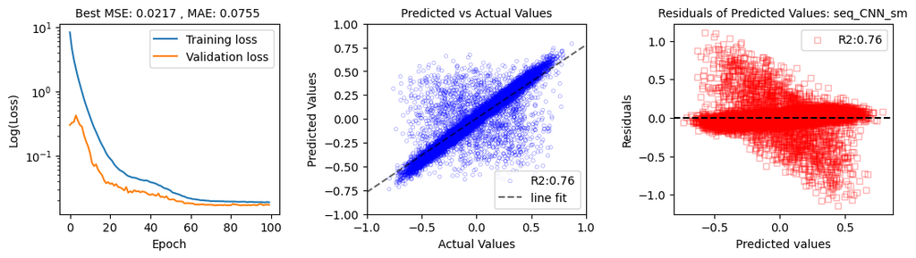

```python
model_evaluate_and_plot(model_sm2,history_sm2,X_test2,y_test2)
```

## there is definatly something wrong with the X2 generated data

## dont use it , just try build models with fresh data

```
(array([ 5, 11, 25, 27, 29, 31, 42, 43, 64, 71, 72, 73, 91, 94, 98, 99]),)
```

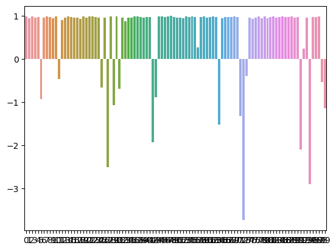

```python
y_pred = model_sm2.predict(X_test2)
r2scores = [ r2_score(y_test2[i], y_pred[i]) for i in range(100) ]
sns.barplot(x=np.arange(100), y=r2scores)
bad_data=X_test2[np.where(np.array(r2scores) < 0)]
np.where(np.array(r2scores) < 0)
```

```python
bad_y_test=y_test2[np.where(np.array(r2scores) < 0)]
```

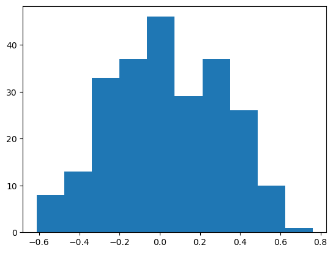

```python
plt.hist(bad_y_test.flatten())
```

```python
np.shape(bad_data.reshape(16,64,64))
```

```
(16, 64, 64)
```

```python
fig = px.imshow(bad_data.reshape(16,64,64), binary_string=True, animation_frame=0, zmax=4)
fig.show()
```

[interactive chart not shown]

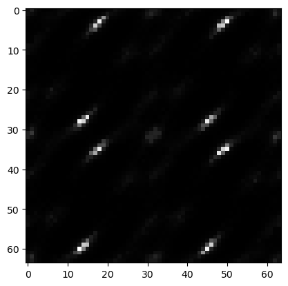

```python
plt.imshow(bad_data.reshape(16,64,64)[2],cmap='gray')
```

# Check the fresh batch X3a on a small model

```python
X_train3a, X_test3a, y_train3a, y_test3a = train_test_split(X3a, y3a, random_state=42,test_size=0.2)


X_train3a=np.expand_dims(X_train3a, -1)
X_test3a=np.expand_dims(X_test3a, -1)


print(np.shape(X_train3a),type(X_train3a))
print(np.shape(X_test3a),type(X_test3a))
print(np.shape(y_train3a),type(y_train3a))
print(np.shape(y_test3a),type(y_test3a))
```

```
(800, 64, 64, 1) <class 'numpy.ndarray'>
(200, 64, 64, 1) <class 'numpy.ndarray'>
(800, 15) <class 'numpy.ndarray'>
(200, 15) <class 'numpy.ndarray'>
```

```python
# build and compile a new model
model_sm3a=construct_new_small_cfs_model(15)

batch_size = 32
epochs = 100
# Define checkpoint callback
checkpoint = ModelCheckpoint('cfs4_sm_X3a.h5', monitor='val_loss', save_best_only=True, mode='min', verbose=1)
# opt = keras.optimizers.Adam(learning_rate=0.01) # not using this atm

# optionally Load  saved weights into the model
# model.load_weights('cfs4_sm_X3a.h5')

model_sm3a.compile(loss="mse", optimizer="adam", metrics=[MeanSquaredError(),MeanAbsoluteError()])
```

```python
# begin training
history_sm3a =model_sm3a.fit(X_train3a,y_train3a,batch_size=batch_size, epochs=epochs, validation_split=0.2,callbacks=[checkpoint])
```

```
Epoch 1: val_loss improved from inf to 0.20065, saving model to cfs4_sm_X3a.h5
Epoch 2: val_loss did not improve from 0.20065
Epoch 3: val_loss did not improve from 0.20065
Epoch 4: val_loss did not improve from 0.20065
Epoch 5: val_loss did not improve from 0.20065
Epoch 6: val_loss did not improve from 0.20065
Epoch 7: val_loss did not improve from 0.20065
Epoch 8: val_loss did not improve from 0.20065
Epoch 9: val_loss did not improve from 0.20065
Epoch 10: val_loss did not improve from 0.20065
Epoch 11: val_loss did not improve from 0.20065
Epoch 12: val_loss did not improve from 0.20065
Epoch 13: val_loss did not improve from 0.20065
Epoch 14: val_loss did not improve from 0.20065
Epoch 15: val_loss did not improve from 0.20065
Epoch 16: val_loss did not improve from 0.20065
Epoch 17: val_loss did not improve from 0.20065
Epoch 18: val_loss did not improve from 0.20065
Epoch 19: val_loss did not improve from 0.20065
Epoch 20: val_loss did not improve from 0.20065
Epoch 21: val_loss did not improve from 0.20065
Epoch 22: val_loss did not improve from 0.20065
Epoch 23: val_loss did not improve from 0.20065
Epoch 24: val_loss did not improve from 0.20065
Epoch 25: val_loss did not improve from 0.20065
Epoch 26: val_loss did not improve from 0.20065
Epoch 27: val_loss did not improve from 0.20065
Epoch 28: val_loss did not improve from 0.20065
Epoch 29: val_loss did not improve from 0.20065
Epoch 30: val_loss did not improve from 0.20065
Epoch 31: val_loss did not improve from 0.20065
Epoch 32: val_loss did not improve from 0.20065
Epoch 33: val_loss did not improve from 0.20065
Epoch 34: val_loss did not improve from 0.20065
Epoch 35: val_loss did not improve from 0.20065
Epoch 36: val_loss did not improve from 0.20065
Epoch 37: val_loss did not improve from 0.20065
Epoch 38: val_loss improved from 0.20065 to 0.15232, saving model to cfs4_sm_X3a.h5
Epoch 39: val_loss did not improve from 0.15232
Epoch 40: val_loss improved from 0.15232 to 0.13416, saving model to cfs4_sm_X3a.h5
```

[output cut: 45 more lines]

```
Epoch 86: val_loss did not improve from 0.02152
Epoch 87: val_loss did not improve from 0.02152
Epoch 88: val_loss did not improve from 0.02152
Epoch 89: val_loss did not improve from 0.02152
Epoch 90: val_loss did not improve from 0.02152
Epoch 91: val_loss improved from 0.02152 to 0.01980, saving model to cfs4_sm_X3a.h5
Epoch 92: val_loss improved from 0.01980 to 0.01858, saving model to cfs4_sm_X3a.h5
Epoch 93: val_loss did not improve from 0.01858
Epoch 94: val_loss improved from 0.01858 to 0.01825, saving model to cfs4_sm_X3a.h5
Epoch 95: val_loss did not improve from 0.01825
Epoch 96: val_loss did not improve from 0.01825
Epoch 97: val_loss did not improve from 0.01825
Epoch 98: val_loss improved from 0.01825 to 0.01562, saving model to cfs4_sm_X3a.h5
Epoch 99: val_loss did not improve from 0.01562
Epoch 100: val_loss did not improve from 0.01562
```

```
Loss: 0.014554951339960098
Mean Square Error: 0.014554951339960098
Mean Absolute Error: 0.09344690293073654
Test R2 score: 0.8350145658715739
```

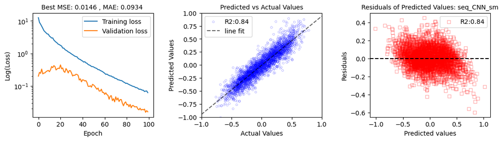

```python
model_evaluate_and_plot(model_sm3a,history_sm3a,X_test3a,y_test3a)
```

### further Train on more data

```
cfs4_big_bin_2
         00        01        02        03        10        11        12  \
0  0.999997 -0.087677  0.145396  0.525171 -0.058597 -0.091583  0.549910
1  0.999782  0.423393  0.202039  0.274956  0.327039  0.026258  0.479817
2  0.999909  0.401385  0.482982 -0.045230 -0.027435  0.029423 -0.464067
3  0.999936  0.457835  0.199154 -0.107269  0.077192 -0.042165 -0.249196
4  0.999852  0.202109  0.202543 -0.316988 -0.235825 -0.265773 -0.181571

         13        20        21        22        23        30        31  \
0 -0.437503 -0.340715  0.404077 -0.347659 -0.119795 -0.024743 -0.322486
1  0.603081  0.306206  0.198133  0.472004  0.301432  0.411675  0.524088
2 -0.373789 -0.293060 -0.642452 -0.273529 -0.503129 -0.362070  0.058937
3  0.072418 -0.556054 -0.488346 -0.351193 -0.171505 -0.095551  0.057227
4  0.098811 -0.182439  0.104887 -0.398585 -0.108655 -0.279228  0.309748

         32        33
0 -0.308597  0.179684
1  0.621744  0.167751
2  0.019440  0.338885
3  0.252540 -0.117252
4  0.383967  0.441259
(800, 64, 64, 1) <class 'numpy.ndarray'>
(200, 64, 64, 1) <class 'numpy.ndarray'>
(800, 15) <class 'numpy.ndarray'>
(200, 15) <class 'numpy.ndarray'>
0.25286022649172446
0.06962137296795845
34.149681091308594
0.005863279569894075
```

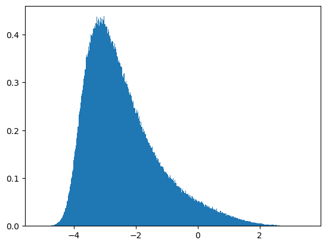

```python
 df_cfs4b3b, X3b, y3b, X_train3b, X_test3b, y_train3b, y_test3b = prep_img_data('cfs4_big_bin_2.h5', 'cfs4_big_corr_out_2.csv',cfs=4)
```

```
cfs4_big_bin_3
         00        01        02        03        10        11        12  \
0  0.999932 -0.243558  0.040731  0.326755 -0.149808 -0.184964  0.385349
1  0.999958  0.272093  0.211329  0.115843  0.179645  0.390583  0.298135
2  0.999204 -0.140553  0.191478  0.415871 -0.051577  0.231843  0.370298
3  0.999896  0.214740 -0.235347  0.012049  0.171337 -0.305660 -0.326493
4  0.999868  0.099260  0.321048 -0.121660  0.429121 -0.119490  0.111847

         13        20        21        22        23        30        31  \
0 -0.312568 -0.209269 -0.262221  0.108439 -0.129408  0.131876  0.363213
1 -0.113758  0.096746 -0.323827 -0.167143 -0.055598  0.121485 -0.170615
2 -0.221282  0.095124  0.082971 -0.034216  0.358579  0.086444  0.419777
3 -0.273542 -0.375104 -0.565642 -0.120330  0.074983 -0.628142  0.012917
4 -0.246660  0.438236 -0.195445  0.217316 -0.367754  0.583635  0.132246

         32        33
0 -0.000068 -0.299547
1 -0.452733 -0.592924
2  0.101635 -0.139251
3  0.446077  0.009879
4  0.551517  0.107507
(800, 64, 64, 1) <class 'numpy.ndarray'>
(200, 64, 64, 1) <class 'numpy.ndarray'>
(800, 15) <class 'numpy.ndarray'>
(200, 15) <class 'numpy.ndarray'>
0.25305830813776947
0.06957972794771194
41.80085372924805
0.0057398974895477295
```

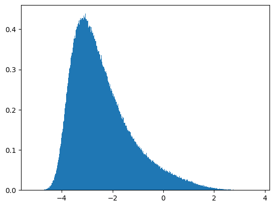

```python
 df_cfs4b3c, X3c, y3c, X_train3c, X_test3c, y_train3c, y_test3c = prep_img_data('cfs4_big_bin_3.h5', 'cfs4_big_corr_out_3.csv',cfs=4)
```

```
cfs4_big_bin_4
         00        01        02        03        10        11        12  \
0  0.999887 -0.125981 -0.384662 -0.150721  0.003359 -0.312613  0.048932
1  0.999999 -0.010418 -0.209637 -0.453126 -0.281251 -0.047744  0.445311
2  0.999988 -0.002182 -0.502616  0.325509  0.270821 -0.273450 -0.165377
3  0.999999  0.003471 -0.553821 -0.208769 -0.059463 -0.020400 -0.243491
4  0.999763 -0.269769 -0.416904  0.166863  0.116950 -0.345289  0.248461

         13        20        21        22        23        30        31  \
0 -0.157665 -0.133794 -0.307405  0.357960  0.269852 -0.224071  0.507265
1  0.018228  0.000867 -0.028213 -0.041668 -0.325088 -0.427953  0.137586
2  0.373686  0.237835  0.094172 -0.436210 -0.168849  0.661012 -0.054266
3 -0.035157 -0.546876 -0.372831  0.380207  0.539061  0.059027  0.175780
4 -0.004578 -0.227234  0.047072 -0.005446 -0.035394 -0.452060  0.458964

         32        33
0  0.288515 -0.492735
1 -0.181859  0.286023
2 -0.534300  0.365873
3  0.052082 -0.062067
4  0.083096 -0.156053
(800, 64, 64, 1) <class 'numpy.ndarray'>
(200, 64, 64, 1) <class 'numpy.ndarray'>
(800, 15) <class 'numpy.ndarray'>
(200, 15) <class 'numpy.ndarray'>
0.2522898752774928
0.0700620487332344
40.3973388671875
0.006213907618075609
```

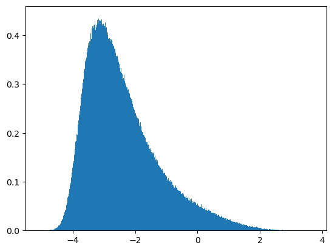

```python
 df_cfs4b3d, X3d, y3d, X_train3d, X_test3d, y_train3d, y_test3d = prep_img_data('cfs4_big_bin_4.h5', 'cfs4_big_corr_out_4.csv',cfs=4)
```

```
cfs4_big_bin_5
         00        01        02        03        10        11        12  \
0  0.999936 -0.372894  0.257314 -0.258311 -0.083832  0.130578  0.044206
1  0.999966 -0.001336  0.011684  0.416198  0.379740  0.157084  0.261684
2  0.999986 -0.219632  0.394518  0.252591 -0.392375 -0.065986 -0.079441
3  0.999882 -0.318694  0.219934  0.179570 -0.187184  0.641809 -0.057843
4  0.999921 -0.181937 -0.124211 -0.418916 -0.000513  0.127959  0.244713

         13        20        21        22        23        30        31  \
0  0.451324 -0.503971  0.563304 -0.347721  0.134050 -0.149804 -0.307790
1  0.505608 -0.129375  0.149271 -0.046041  0.389289 -0.138489  0.013855
2 -0.524319 -0.178833  0.379327 -0.217028  0.455282  0.677938 -0.371107
3  0.039379 -0.205847  0.026358  0.328007  0.153528  0.645716 -0.408972
4 -0.390704  0.068497  0.482560 -0.338187 -0.166312 -0.244003  0.383167

         32        33
0  0.245161 -0.182790
1 -0.493958  0.138421
2  0.352417  0.006497
3  0.127920  0.152226
4  0.232994  0.148358
(800, 64, 64, 1) <class 'numpy.ndarray'>
(200, 64, 64, 1) <class 'numpy.ndarray'>
(800, 15) <class 'numpy.ndarray'>
(200, 15) <class 'numpy.ndarray'>
0.25308211562980704
0.06933529302477837
46.72438430786133
0.007030986249446869
```

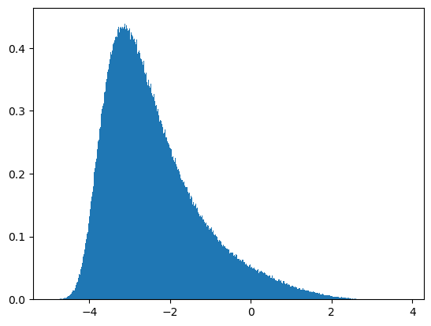

```python
 df_cfs4b3e, X3e, y3e, X_train3e, X_test3e, y_train3e, y_test3e = prep_img_data('cfs4_big_bin_5.h5', 'cfs4_big_corr_out_5.csv',cfs=4)
```

```python
history_sm3b =model_sm3a.fit(X_train3b,y_train3b,batch_size=batch_size, epochs=epochs, validation_split=0.2,callbacks=[checkpoint])
```

```
Epoch 1: val_loss did not improve from 0.01562
Epoch 2: val_loss improved from 0.01562 to 0.01506, saving model to cfs4_sm_X3a.h5
Epoch 3: val_loss improved from 0.01506 to 0.01430, saving model to cfs4_sm_X3a.h5
Epoch 4: val_loss improved from 0.01430 to 0.01391, saving model to cfs4_sm_X3a.h5
Epoch 5: val_loss did not improve from 0.01391
Epoch 6: val_loss improved from 0.01391 to 0.01239, saving model to cfs4_sm_X3a.h5
Epoch 7: val_loss did not improve from 0.01239
Epoch 8: val_loss did not improve from 0.01239
Epoch 9: val_loss improved from 0.01239 to 0.01211, saving model to cfs4_sm_X3a.h5
Epoch 10: val_loss did not improve from 0.01211
Epoch 11: val_loss improved from 0.01211 to 0.01208, saving model to cfs4_sm_X3a.h5
Epoch 12: val_loss did not improve from 0.01208
Epoch 13: val_loss improved from 0.01208 to 0.01117, saving model to cfs4_sm_X3a.h5
Epoch 14: val_loss did not improve from 0.01117
Epoch 15: val_loss did not improve from 0.01117
Epoch 16: val_loss did not improve from 0.01117
Epoch 17: val_loss improved from 0.01117 to 0.00890, saving model to cfs4_sm_X3a.h5
Epoch 18: val_loss did not improve from 0.00890
Epoch 19: val_loss did not improve from 0.00890
Epoch 20: val_loss did not improve from 0.00890
Epoch 21: val_loss did not improve from 0.00890
Epoch 22: val_loss improved from 0.00890 to 0.00850, saving model to cfs4_sm_X3a.h5
Epoch 23: val_loss improved from 0.00850 to 0.00821, saving model to cfs4_sm_X3a.h5
Epoch 24: val_loss did not improve from 0.00821
Epoch 25: val_loss improved from 0.00821 to 0.00800, saving model to cfs4_sm_X3a.h5
Epoch 26: val_loss did not improve from 0.00800
Epoch 27: val_loss improved from 0.00800 to 0.00772, saving model to cfs4_sm_X3a.h5
Epoch 28: val_loss did not improve from 0.00772
Epoch 29: val_loss did not improve from 0.00772
Epoch 30: val_loss did not improve from 0.00772
Epoch 31: val_loss did not improve from 0.00772
Epoch 32: val_loss did not improve from 0.00772
Epoch 33: val_loss did not improve from 0.00772
Epoch 34: val_loss improved from 0.00772 to 0.00715, saving model to cfs4_sm_X3a.h5
Epoch 35: val_loss improved from 0.00715 to 0.00618, saving model to cfs4_sm_X3a.h5
Epoch 36: val_loss did not improve from 0.00618
Epoch 37: val_loss did not improve from 0.00618
Epoch 38: val_loss did not improve from 0.00618
Epoch 39: val_loss did not improve from 0.00618
Epoch 40: val_loss did not improve from 0.00618
```

[output cut: 45 more lines]

```
Epoch 86: val_loss improved from 0.00504 to 0.00498, saving model to cfs4_sm_X3a.h5
Epoch 87: val_loss did not improve from 0.00498
Epoch 88: val_loss improved from 0.00498 to 0.00471, saving model to cfs4_sm_X3a.h5
Epoch 89: val_loss did not improve from 0.00471
Epoch 90: val_loss did not improve from 0.00471
Epoch 91: val_loss did not improve from 0.00471
Epoch 92: val_loss did not improve from 0.00471
Epoch 93: val_loss did not improve from 0.00471
Epoch 94: val_loss did not improve from 0.00471
Epoch 95: val_loss did not improve from 0.00471
Epoch 96: val_loss did not improve from 0.00471
Epoch 97: val_loss did not improve from 0.00471
Epoch 98: val_loss did not improve from 0.00471
Epoch 99: val_loss did not improve from 0.00471
Epoch 100: val_loss did not improve from 0.00471
```

```
Loss: 0.005336812697350979
Mean Square Error: 0.005336812697350979
Mean Absolute Error: 0.056449633091688156
Test R2 score: 0.941194143664118
```

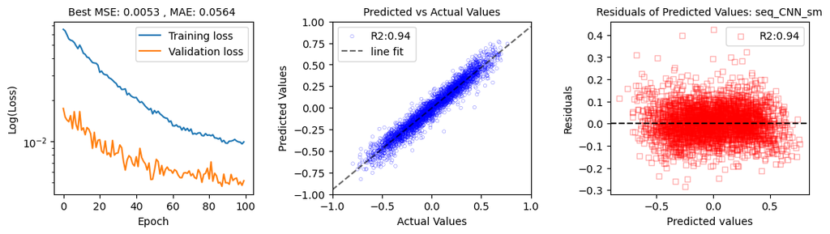

```python
model_evaluate_and_plot(model_sm3a,history_sm3b,X_test3b,y_test3b)
```

```
Loss: 0.005138309206813574
Mean Square Error: 0.005138309206813574
Mean Absolute Error: 0.05558069050312042
Test R2 score: 0.9417554872329483
```

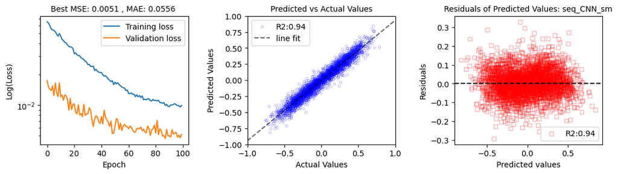

```python
model_evaluate_and_plot(model_sm3a,history_sm3b,X_test3a,y_test3a)
```

### that worked out lets save that model and further train a new one

#### the small model that has been trained incremetally is saved as 'cfs4_sm_X3b.h5'

We are using a technique called incremental learning, where you gradually introduce new data to the model and update its weights accordingly. This can be a useful technique when working with large datasets or when the model needs to be updated with new data over time. In your case, you are splitting the training data into 5 folds of 1000 data points and training the model on each fold separately using a batch size of 32 and 100 epochs before introducing the next fold of data and updating the model weights. This approach can help to reduce the memory requirements of the model and allow for more frequent updates to the weights, which can lead to faster convergence and better generalization performance. However, it is important to note that the choice of batch size and number of epochs can have an impact on the performance of the model, and these parameters may need to be tuned for optimal performance

```python
# build and compile a new model
model_sm3b=construct_new_small_cfs_model(15)

batch_size = 32
epochs = 100
# Define checkpoint callback
checkpoint = ModelCheckpoint('cfs4_sm_X3b.h5', monitor='val_loss', save_best_only=True, mode='min', verbose=1)
# opt = keras.optimizers.Adam(learning_rate=0.01) # not using this atm

# optionally Load  saved weights into the model
model_sm3b.load_weights('cfs4_sm_X3a.h5')

model_sm3b.compile(loss="mse", optimizer="adam", metrics=[MeanSquaredError(),MeanAbsoluteError()])
```

```python
history_sm3b =model_sm3b.fit(X_train3c,y_train3c,batch_size=batch_size, epochs=epochs, validation_split=0.2,callbacks=[checkpoint])
```

```
Epoch 1: val_loss improved from inf to 0.07782, saving model to cfs4_sm_X3b.h5
Epoch 2: val_loss improved from 0.07782 to 0.06996, saving model to cfs4_sm_X3b.h5
Epoch 3: val_loss improved from 0.06996 to 0.05483, saving model to cfs4_sm_X3b.h5
Epoch 4: val_loss improved from 0.05483 to 0.03827, saving model to cfs4_sm_X3b.h5
Epoch 5: val_loss did not improve from 0.03827
Epoch 6: val_loss did not improve from 0.03827
Epoch 7: val_loss improved from 0.03827 to 0.03296, saving model to cfs4_sm_X3b.h5
Epoch 8: val_loss improved from 0.03296 to 0.02628, saving model to cfs4_sm_X3b.h5
Epoch 9: val_loss improved from 0.02628 to 0.02326, saving model to cfs4_sm_X3b.h5
Epoch 10: val_loss did not improve from 0.02326
Epoch 11: val_loss did not improve from 0.02326
Epoch 12: val_loss improved from 0.02326 to 0.01487, saving model to cfs4_sm_X3b.h5
Epoch 13: val_loss did not improve from 0.01487
Epoch 14: val_loss improved from 0.01487 to 0.01341, saving model to cfs4_sm_X3b.h5
Epoch 15: val_loss improved from 0.01341 to 0.01096, saving model to cfs4_sm_X3b.h5
Epoch 16: val_loss did not improve from 0.01096
Epoch 17: val_loss improved from 0.01096 to 0.00928, saving model to cfs4_sm_X3b.h5
Epoch 18: val_loss improved from 0.00928 to 0.00867, saving model to cfs4_sm_X3b.h5
Epoch 19: val_loss improved from 0.00867 to 0.00857, saving model to cfs4_sm_X3b.h5
Epoch 20: val_loss improved from 0.00857 to 0.00802, saving model to cfs4_sm_X3b.h5
Epoch 21: val_loss improved from 0.00802 to 0.00699, saving model to cfs4_sm_X3b.h5
Epoch 22: val_loss improved from 0.00699 to 0.00646, saving model to cfs4_sm_X3b.h5
Epoch 23: val_loss improved from 0.00646 to 0.00537, saving model to cfs4_sm_X3b.h5
Epoch 24: val_loss did not improve from 0.00537
Epoch 25: val_loss improved from 0.00537 to 0.00480, saving model to cfs4_sm_X3b.h5
Epoch 26: val_loss did not improve from 0.00480
Epoch 27: val_loss improved from 0.00480 to 0.00403, saving model to cfs4_sm_X3b.h5
Epoch 28: val_loss improved from 0.00403 to 0.00341, saving model to cfs4_sm_X3b.h5
Epoch 29: val_loss improved from 0.00341 to 0.00311, saving model to cfs4_sm_X3b.h5
Epoch 30: val_loss did not improve from 0.00311
Epoch 31: val_loss did not improve from 0.00311
Epoch 32: val_loss improved from 0.00311 to 0.00301, saving model to cfs4_sm_X3b.h5
Epoch 33: val_loss did not improve from 0.00301
Epoch 34: val_loss improved from 0.00301 to 0.00262, saving model to cfs4_sm_X3b.h5
Epoch 35: val_loss did not improve from 0.00262
Epoch 36: val_loss did not improve from 0.00262
Epoch 37: val_loss improved from 0.00262 to 0.00250, saving model to cfs4_sm_X3b.h5
Epoch 38: val_loss improved from 0.00250 to 0.00227, saving model to cfs4_sm_X3b.h5
Epoch 39: val_loss improved from 0.00227 to 0.00221, saving model to cfs4_sm_X3b.h5
Epoch 40: val_loss improved from 0.00221 to 0.00198, saving model to cfs4_sm_X3b.h5
```

[output cut: 45 more lines]

```
Epoch 86: val_loss did not improve from 0.00069
Epoch 87: val_loss did not improve from 0.00069
Epoch 88: val_loss did not improve from 0.00069
Epoch 89: val_loss did not improve from 0.00069
Epoch 90: val_loss did not improve from 0.00069
Epoch 91: val_loss improved from 0.00069 to 0.00062, saving model to cfs4_sm_X3b.h5
Epoch 92: val_loss did not improve from 0.00062
Epoch 93: val_loss did not improve from 0.00062
Epoch 94: val_loss improved from 0.00062 to 0.00061, saving model to cfs4_sm_X3b.h5
Epoch 95: val_loss did not improve from 0.00061
Epoch 96: val_loss did not improve from 0.00061
Epoch 97: val_loss did not improve from 0.00061
Epoch 98: val_loss did not improve from 0.00061
Epoch 99: val_loss did not improve from 0.00061
Epoch 100: val_loss did not improve from 0.00061
```

```
Loss: 0.0005634772242046893
Mean Square Error: 0.0005634772242046893
Mean Absolute Error: 0.018712718039751053
Test R2 score: 0.9939006683943048
```

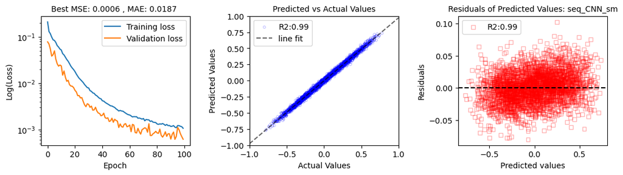

```python
model_evaluate_and_plot(model_sm3b,history_sm3b,X_test3c,y_test3c)
```

```python
history_sm3d =model_sm3b.fit(X_train3d,y_train3d,batch_size=batch_size, epochs=epochs, validation_split=0.2,callbacks=[checkpoint])
```

```
Epoch 1: val_loss improved from 0.00061 to 0.00054, saving model to cfs4_sm_X3b.h5
Epoch 2: val_loss did not improve from 0.00054
Epoch 3: val_loss did not improve from 0.00054
Epoch 4: val_loss did not improve from 0.00054
Epoch 5: val_loss did not improve from 0.00054
Epoch 6: val_loss improved from 0.00054 to 0.00049, saving model to cfs4_sm_X3b.h5
Epoch 7: val_loss did not improve from 0.00049
Epoch 8: val_loss did not improve from 0.00049
Epoch 9: val_loss did not improve from 0.00049
Epoch 10: val_loss did not improve from 0.00049
Epoch 11: val_loss improved from 0.00049 to 0.00047, saving model to cfs4_sm_X3b.h5
Epoch 12: val_loss did not improve from 0.00047
Epoch 13: val_loss did not improve from 0.00047
Epoch 14: val_loss did not improve from 0.00047
Epoch 15: val_loss did not improve from 0.00047
Epoch 16: val_loss did not improve from 0.00047
Epoch 17: val_loss improved from 0.00047 to 0.00046, saving model to cfs4_sm_X3b.h5
Epoch 18: val_loss did not improve from 0.00046
Epoch 19: val_loss did not improve from 0.00046
Epoch 20: val_loss did not improve from 0.00046
Epoch 21: val_loss did not improve from 0.00046
Epoch 22: val_loss did not improve from 0.00046
Epoch 23: val_loss did not improve from 0.00046
Epoch 24: val_loss did not improve from 0.00046
Epoch 25: val_loss did not improve from 0.00046
Epoch 26: val_loss did not improve from 0.00046
Epoch 27: val_loss did not improve from 0.00046
Epoch 28: val_loss did not improve from 0.00046
Epoch 29: val_loss improved from 0.00046 to 0.00044, saving model to cfs4_sm_X3b.h5
Epoch 30: val_loss did not improve from 0.00044
Epoch 31: val_loss did not improve from 0.00044
Epoch 32: val_loss improved from 0.00044 to 0.00044, saving model to cfs4_sm_X3b.h5
Epoch 33: val_loss did not improve from 0.00044
Epoch 34: val_loss did not improve from 0.00044
Epoch 35: val_loss did not improve from 0.00044
Epoch 36: val_loss did not improve from 0.00044
Epoch 37: val_loss did not improve from 0.00044
Epoch 38: val_loss did not improve from 0.00044
Epoch 39: val_loss did not improve from 0.00044
Epoch 40: val_loss did not improve from 0.00044
```

[output cut: 45 more lines]

```
Epoch 86: val_loss did not improve from 0.00040
Epoch 87: val_loss did not improve from 0.00040
Epoch 88: val_loss did not improve from 0.00040
Epoch 89: val_loss did not improve from 0.00040
Epoch 90: val_loss did not improve from 0.00040
Epoch 91: val_loss did not improve from 0.00040
Epoch 92: val_loss did not improve from 0.00040
Epoch 93: val_loss did not improve from 0.00040
Epoch 94: val_loss did not improve from 0.00040
Epoch 95: val_loss did not improve from 0.00040
Epoch 96: val_loss did not improve from 0.00040
Epoch 97: val_loss did not improve from 0.00040
Epoch 98: val_loss did not improve from 0.00040
Epoch 99: val_loss did not improve from 0.00040
Epoch 100: val_loss did not improve from 0.00040
```

```
Loss: 0.000425750098656863
Mean Square Error: 0.000425750098656863
Mean Absolute Error: 0.016029328107833862
Test R2 score: 0.9952119018825233
```

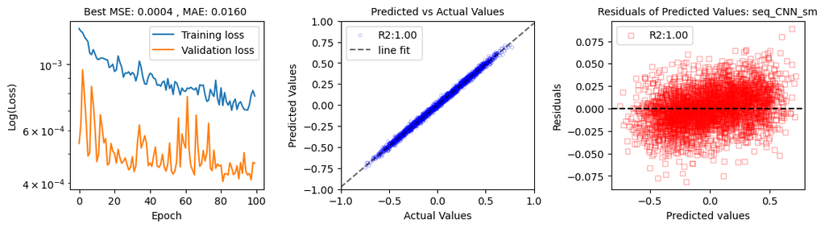

```python
model_evaluate_and_plot(model_sm3b,history_sm3d,X_test3d,y_test3d)
```

```python
history_sm3e =model_sm3b.fit(X_train3e,y_train3e,batch_size=batch_size, epochs=epochs, validation_split=0.2,callbacks=[checkpoint])
```

```
Epoch 1: val_loss improved from 0.00040 to 0.00037, saving model to cfs4_sm_X3b.h5
Epoch 2: val_loss did not improve from 0.00037
Epoch 3: val_loss did not improve from 0.00037
Epoch 4: val_loss improved from 0.00037 to 0.00036, saving model to cfs4_sm_X3b.h5
Epoch 5: val_loss did not improve from 0.00036
Epoch 6: val_loss did not improve from 0.00036
Epoch 7: val_loss did not improve from 0.00036
Epoch 8: val_loss improved from 0.00036 to 0.00034, saving model to cfs4_sm_X3b.h5
Epoch 9: val_loss did not improve from 0.00034
Epoch 10: val_loss did not improve from 0.00034
Epoch 11: val_loss did not improve from 0.00034
Epoch 12: val_loss did not improve from 0.00034
Epoch 13: val_loss did not improve from 0.00034
Epoch 14: val_loss did not improve from 0.00034
Epoch 15: val_loss did not improve from 0.00034
Epoch 16: val_loss improved from 0.00034 to 0.00034, saving model to cfs4_sm_X3b.h5
Epoch 17: val_loss did not improve from 0.00034
Epoch 18: val_loss did not improve from 0.00034
Epoch 19: val_loss did not improve from 0.00034
Epoch 20: val_loss did not improve from 0.00034
Epoch 21: val_loss improved from 0.00034 to 0.00034, saving model to cfs4_sm_X3b.h5
Epoch 22: val_loss did not improve from 0.00034
Epoch 23: val_loss did not improve from 0.00034
Epoch 24: val_loss did not improve from 0.00034
Epoch 25: val_loss did not improve from 0.00034
Epoch 26: val_loss did not improve from 0.00034
Epoch 27: val_loss did not improve from 0.00034
Epoch 28: val_loss did not improve from 0.00034
Epoch 29: val_loss improved from 0.00034 to 0.00033, saving model to cfs4_sm_X3b.h5
Epoch 30: val_loss did not improve from 0.00033
Epoch 31: val_loss did not improve from 0.00033
Epoch 32: val_loss did not improve from 0.00033
Epoch 33: val_loss did not improve from 0.00033
Epoch 34: val_loss did not improve from 0.00033
Epoch 35: val_loss did not improve from 0.00033
Epoch 36: val_loss did not improve from 0.00033
Epoch 37: val_loss did not improve from 0.00033
Epoch 38: val_loss did not improve from 0.00033
Epoch 39: val_loss did not improve from 0.00033
Epoch 40: val_loss did not improve from 0.00033
```

[output cut: 45 more lines]

```
Epoch 86: val_loss did not improve from 0.00033
Epoch 87: val_loss did not improve from 0.00033
Epoch 88: val_loss did not improve from 0.00033
Epoch 89: val_loss did not improve from 0.00033
Epoch 90: val_loss did not improve from 0.00033
Epoch 91: val_loss did not improve from 0.00033
Epoch 92: val_loss did not improve from 0.00033
Epoch 93: val_loss did not improve from 0.00033
Epoch 94: val_loss did not improve from 0.00033
Epoch 95: val_loss did not improve from 0.00033
Epoch 96: val_loss did not improve from 0.00033
Epoch 97: val_loss did not improve from 0.00033
Epoch 98: val_loss did not improve from 0.00033
Epoch 99: val_loss did not improve from 0.00033
Epoch 100: val_loss did not improve from 0.00033
```

```
Loss: 0.00043499638559296727
Mean Square Error: 0.00043499638559296727
Mean Absolute Error: 0.01592227816581726
Test R2 score: 0.9952594050725498
```

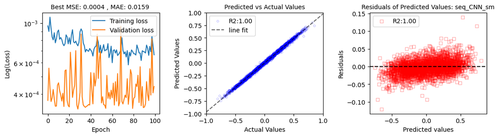

```python
model_evaluate_and_plot(model_sm3b,history_sm3e,X_test3e,y_test3e)
```

### Regeneration tests on random test cfs vectors

```
[ 1.       -0.108231 -0.26752  -0.145992 -0.072207  0.275015 -0.404672
 -0.214134 -0.092172 -0.192433 -0.019256 -0.420731 -0.031842 -0.621252
 -0.08002   0.502012]
[[ 1.       -0.108231 -0.26752  -0.145992]
 [-0.072207  0.275015 -0.404672 -0.214134]
 [-0.092172 -0.192433 -0.019256 -0.420731]
 [-0.031842 -0.621252 -0.08002   0.502012]]
```

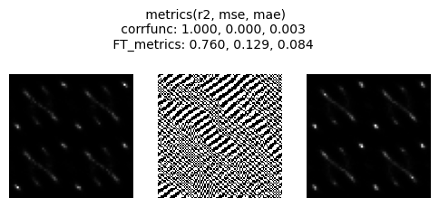

```python
xvar=np.random.randint(0,np.shape(X_test3a)[0],1)[0]
regenerate_test_cfs_vector_and_compare(calc_diffuse_cfs4_big,X_test3a,y_test3a,xvar,cfs=4)
```

```python
y_pred3a = model_sm3b.predict(X_test3a)
```

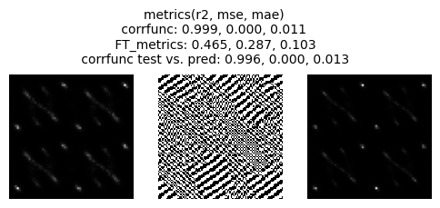

```python
regenerate_pred_cfs_vector_and_compare(calc_diffuse_cfs4_big,X_test3a,y_test3a,y_pred3a,xvar,cfs=4)
```

# Here begins some earlier tests which did not work out so well

```python
# Evaluate the model on the train set
y_pred = model_sm.predict(X_train2)
r2 = r2_score(y_train2.flatten(), y_pred.flatten())
print("Test R2 score:", r2)
```

```
Test R2 score: 0.8311022570285096
```

```python
m,b=np.polyfit(y_train2.flatten(),y_pred.flatten(),1)
xs=np.linspace(-1,1,10)
ys=m*xs+b
```

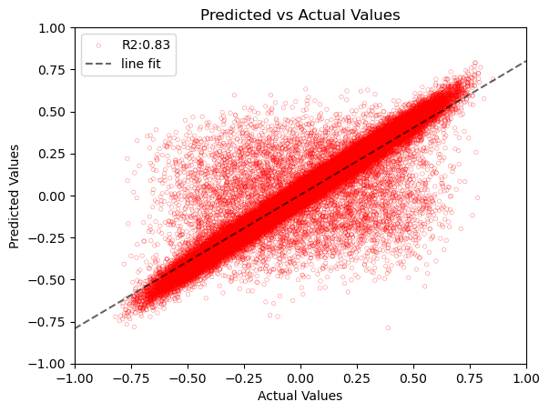

```python
ax=sns.scatterplot(x=y_train2.flatten(),y=y_pred.flatten(),marker='o',edgecolor='r',c='none',s=10,alpha=0.7,label='R2:%.2f'%r2)
ax=plt.plot(xs,ys,c='k',marker='none',linestyle='--',alpha=0.6,label='line fit')
ax=plt.legend()
ax=plt.xlim([-1.0,1.0])
ax=plt.ylim([-1.0,1.0])
ax=plt.margins(0.25)
ax=plt.xlabel('Actual Values')
ax=plt.ylabel('Predicted Values')
ax=plt.title('Predicted vs Actual Values')
```

#### medium sized model fitted to X1 was saved as 'cfs4_big_best_model_5000_p1.h5'

```python
batch_size = 32
epochs = 100
# Define checkpoint callback
checkpoint = ModelCheckpoint('cfs4_big_best_model_5000_p1.h5', monitor='val_loss', save_best_only=True, mode='min', verbose=1)
# opt = keras.optimizers.Adam(learning_rate=0.01) # not using this atm
model.compile(loss="mse", optimizer="adam", metrics=[MeanSquaredError(),MeanAbsoluteError()])
```

```python
history =model.fit(X_train,y_train,batch_size=batch_size, epochs=epochs, validation_split=0.2,callbacks=[checkpoint])

# ## Evaluate the trained model

# In[ ]:
```

```
Epoch 1: val_loss improved from inf to 0.16907, saving model to cfs4_big_best_model_5000_p1.h5
Epoch 2: val_loss improved from 0.16907 to 0.04795, saving model to cfs4_big_best_model_5000_p1.h5
Epoch 3: val_loss improved from 0.04795 to 0.03140, saving model to cfs4_big_best_model_5000_p1.h5
Epoch 4: val_loss improved from 0.03140 to 0.02286, saving model to cfs4_big_best_model_5000_p1.h5
Epoch 5: val_loss improved from 0.02286 to 0.01746, saving model to cfs4_big_best_model_5000_p1.h5
Epoch 6: val_loss improved from 0.01746 to 0.01536, saving model to cfs4_big_best_model_5000_p1.h5
Epoch 7: val_loss improved from 0.01536 to 0.01365, saving model to cfs4_big_best_model_5000_p1.h5
Epoch 8: val_loss improved from 0.01365 to 0.01235, saving model to cfs4_big_best_model_5000_p1.h5
Epoch 9: val_loss improved from 0.01235 to 0.01175, saving model to cfs4_big_best_model_5000_p1.h5
Epoch 10: val_loss did not improve from 0.01175
Epoch 11: val_loss did not improve from 0.01175
Epoch 12: val_loss improved from 0.01175 to 0.01007, saving model to cfs4_big_best_model_5000_p1.h5
Epoch 13: val_loss improved from 0.01007 to 0.00906, saving model to cfs4_big_best_model_5000_p1.h5
Epoch 14: val_loss improved from 0.00906 to 0.00823, saving model to cfs4_big_best_model_5000_p1.h5
Epoch 15: val_loss improved from 0.00823 to 0.00781, saving model to cfs4_big_best_model_5000_p1.h5
Epoch 16: val_loss improved from 0.00781 to 0.00743, saving model to cfs4_big_best_model_5000_p1.h5
Epoch 17: val_loss improved from 0.00743 to 0.00670, saving model to cfs4_big_best_model_5000_p1.h5
Epoch 18: val_loss improved from 0.00670 to 0.00629, saving model to cfs4_big_best_model_5000_p1.h5
Epoch 19: val_loss improved from 0.00629 to 0.00606, saving model to cfs4_big_best_model_5000_p1.h5
Epoch 20: val_loss improved from 0.00606 to 0.00576, saving model to cfs4_big_best_model_5000_p1.h5
Epoch 21: val_loss improved from 0.00576 to 0.00533, saving model to cfs4_big_best_model_5000_p1.h5
Epoch 22: val_loss did not improve from 0.00533
Epoch 23: val_loss improved from 0.00533 to 0.00488, saving model to cfs4_big_best_model_5000_p1.h5
Epoch 24: val_loss did not improve from 0.00488
Epoch 25: val_loss improved from 0.00488 to 0.00481, saving model to cfs4_big_best_model_5000_p1.h5
Epoch 26: val_loss improved from 0.00481 to 0.00475, saving model to cfs4_big_best_model_5000_p1.h5
Epoch 27: val_loss improved from 0.00475 to 0.00473, saving model to cfs4_big_best_model_5000_p1.h5
Epoch 28: val_loss improved from 0.00473 to 0.00453, saving model to cfs4_big_best_model_5000_p1.h5
Epoch 29: val_loss improved from 0.00453 to 0.00441, saving model to cfs4_big_best_model_5000_p1.h5
Epoch 30: val_loss did not improve from 0.00441
Epoch 31: val_loss did not improve from 0.00441
Epoch 32: val_loss did not improve from 0.00441
Epoch 33: val_loss did not improve from 0.00441
Epoch 34: val_loss did not improve from 0.00441
Epoch 35: val_loss did not improve from 0.00441
Epoch 36: val_loss did not improve from 0.00441
Epoch 37: val_loss did not improve from 0.00441
Epoch 38: val_loss did not improve from 0.00441
Epoch 39: val_loss did not improve from 0.00441
Epoch 40: val_loss did not improve from 0.00441
```

[output cut: 45 more lines]

```
Epoch 86: val_loss did not improve from 0.00353
Epoch 87: val_loss did not improve from 0.00353
Epoch 88: val_loss did not improve from 0.00353
Epoch 89: val_loss did not improve from 0.00353
Epoch 90: val_loss did not improve from 0.00353
Epoch 91: val_loss did not improve from 0.00353
Epoch 92: val_loss did not improve from 0.00353
Epoch 93: val_loss did not improve from 0.00353
Epoch 94: val_loss did not improve from 0.00353
Epoch 95: val_loss did not improve from 0.00353
Epoch 96: val_loss did not improve from 0.00353
Epoch 97: val_loss improved from 0.00353 to 0.00351, saving model to cfs4_big_best_model_5000_p1.h5
Epoch 98: val_loss did not improve from 0.00351
Epoch 99: val_loss did not improve from 0.00351
Epoch 100: val_loss did not improve from 0.00351
```

```python
score = model.evaluate(X_test, y_test, verbose=1)
print("Test loss:", score[0])
print("Test mae:", score[2])
```

```
Test loss: 0.0041091484017670155
Test mae: 0.05119636282324791
```

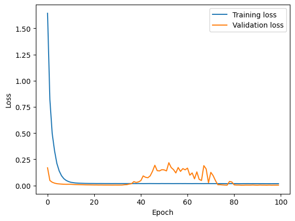

```python
# Plot the training and validation loss as a function of the epoch
plt.plot(history.history['loss'], label='Training loss')
plt.plot(history.history['val_loss'], label='Validation loss')
plt.xlabel('Epoch')
plt.ylabel('Loss')
plt.legend()
```

```python
# Evaluate the model on the test set
y_pred = model.predict(X_test)
r2 = r2_score(y_test.flatten(), y_pred.flatten())
print("Test R2 score:", r2)
```

```
Test R2 score: 0.9552567958325642
```

```python
m,b=np.polyfit(y_test.flatten(),y_pred.flatten(),1)
xs=np.linspace(-1,1,10)
ys=m*xs+b
```

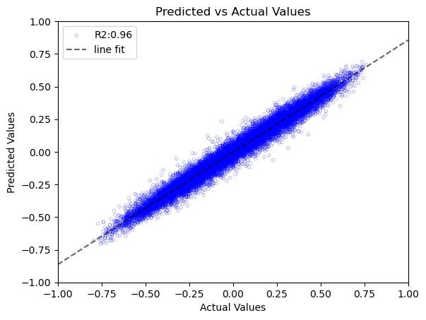

```python
ax=sns.scatterplot(x=y_test.flatten(),y=y_pred.flatten(),marker='o',edgecolor='b',c='none',s=10,alpha=0.7,label='R2:%.2f'%r2)
ax=plt.plot(xs,ys,c='k',marker='none',linestyle='--',alpha=0.6,label='line fit')
ax=plt.legend()
ax=plt.xlim([-1.0,1.0])
ax=plt.ylim([-1.0,1.0])
ax=plt.margins(0.25)
ax=plt.xlabel('Actual Values')
ax=plt.ylabel('Predicted Values')
ax=plt.title('Predicted vs Actual Values')
```

### large model trained on X12 and saved as cfs4_big_best_model_5000_p12.h5

```python
# Load the saved weights into the model
# model.load_weights('cfs4_big_best_model_5000_p12.h5')

batch_size = 64
epochs = 100
# Define checkpoint callback
checkpoint = ModelCheckpoint('cfs4_big_best_model_5000_p12.h5', monitor='val_loss', save_best_only=True, mode='min', verbose=1)
# opt = keras.optimizers.Adam(learning_rate=0.01) # not using this atm

model.compile(loss="mse", optimizer="adam", metrics=[MeanSquaredError(),MeanAbsoluteError()])
# ## Evaluate the trained model
```

```python
history12 =model.fit(X_train12,y_train12,batch_size=batch_size, epochs=epochs, validation_split=0.2,callbacks=[checkpoint])
```

```
Epoch 1: val_loss improved from inf to 0.10300, saving model to cfs4_big_best_model_5000_p12.h5
Epoch 2: val_loss improved from 0.10300 to 0.08203, saving model to cfs4_big_best_model_5000_p12.h5
Epoch 3: val_loss improved from 0.08203 to 0.07816, saving model to cfs4_big_best_model_5000_p12.h5
Epoch 4: val_loss improved from 0.07816 to 0.06787, saving model to cfs4_big_best_model_5000_p12.h5
Epoch 5: val_loss improved from 0.06787 to 0.05503, saving model to cfs4_big_best_model_5000_p12.h5
Epoch 6: val_loss improved from 0.05503 to 0.04151, saving model to cfs4_big_best_model_5000_p12.h5
Epoch 7: val_loss improved from 0.04151 to 0.03189, saving model to cfs4_big_best_model_5000_p12.h5
Epoch 8: val_loss improved from 0.03189 to 0.02544, saving model to cfs4_big_best_model_5000_p12.h5
Epoch 9: val_loss improved from 0.02544 to 0.02176, saving model to cfs4_big_best_model_5000_p12.h5
Epoch 10: val_loss improved from 0.02176 to 0.01971, saving model to cfs4_big_best_model_5000_p12.h5
Epoch 11: val_loss improved from 0.01971 to 0.01604, saving model to cfs4_big_best_model_5000_p12.h5
Epoch 12: val_loss improved from 0.01604 to 0.01571, saving model to cfs4_big_best_model_5000_p12.h5
Epoch 13: val_loss did not improve from 0.01571
Epoch 14: val_loss improved from 0.01571 to 0.01551, saving model to cfs4_big_best_model_5000_p12.h5
Epoch 15: val_loss improved from 0.01551 to 0.01502, saving model to cfs4_big_best_model_5000_p12.h5
Epoch 16: val_loss did not improve from 0.01502
Epoch 17: val_loss did not improve from 0.01502
Epoch 18: val_loss improved from 0.01502 to 0.01479, saving model to cfs4_big_best_model_5000_p12.h5
Epoch 19: val_loss improved from 0.01479 to 0.01455, saving model to cfs4_big_best_model_5000_p12.h5
Epoch 20: val_loss improved from 0.01455 to 0.01449, saving model to cfs4_big_best_model_5000_p12.h5
Epoch 21: val_loss improved from 0.01449 to 0.01436, saving model to cfs4_big_best_model_5000_p12.h5
Epoch 22: val_loss did not improve from 0.01436
Epoch 23: val_loss improved from 0.01436 to 0.01435, saving model to cfs4_big_best_model_5000_p12.h5
Epoch 24: val_loss did not improve from 0.01435
Epoch 25: val_loss improved from 0.01435 to 0.01355, saving model to cfs4_big_best_model_5000_p12.h5
Epoch 26: val_loss improved from 0.01355 to 0.01354, saving model to cfs4_big_best_model_5000_p12.h5
Epoch 27: val_loss did not improve from 0.01354
Epoch 28: val_loss did not improve from 0.01354
Epoch 29: val_loss did not improve from 0.01354
Epoch 30: val_loss did not improve from 0.01354
Epoch 31: val_loss did not improve from 0.01354
Epoch 32: val_loss did not improve from 0.01354
Epoch 33: val_loss did not improve from 0.01354
Epoch 34: val_loss did not improve from 0.01354
Epoch 35: val_loss did not improve from 0.01354
Epoch 36: val_loss did not improve from 0.01354
Epoch 37: val_loss did not improve from 0.01354
Epoch 38: val_loss did not improve from 0.01354
Epoch 39: val_loss did not improve from 0.01354
Epoch 40: val_loss did not improve from 0.01354
```

[output cut: 45 more lines]

```
Epoch 86: val_loss did not improve from 0.01292
Epoch 87: val_loss did not improve from 0.01292
Epoch 88: val_loss did not improve from 0.01292
Epoch 89: val_loss did not improve from 0.01292
Epoch 90: val_loss did not improve from 0.01292
Epoch 91: val_loss did not improve from 0.01292
Epoch 92: val_loss did not improve from 0.01292
Epoch 93: val_loss did not improve from 0.01292
Epoch 94: val_loss did not improve from 0.01292
Epoch 95: val_loss did not improve from 0.01292
Epoch 96: val_loss did not improve from 0.01292
Epoch 97: val_loss did not improve from 0.01292
Epoch 98: val_loss improved from 0.01292 to 0.01203, saving model to cfs4_big_best_model_5000_p12.h5
Epoch 99: val_loss did not improve from 0.01203
Epoch 100: val_loss did not improve from 0.01203
```

```python
score = model.evaluate(X_test12, y_test12, verbose=1)
print("Test loss:", score[0])
print("Test mae:", score[2])
```

```
Test loss: 0.011386232450604439
Test mae: 0.06334599107503891
```

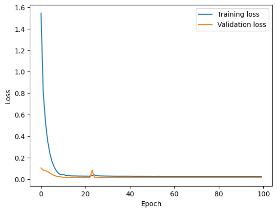

```python
# Plot the training and validation loss as a function of the epoch
plt.plot(history12.history['loss'], label='Training loss')
plt.plot(history12.history['val_loss'], label='Validation loss')
plt.xlabel('Epoch')
plt.ylabel('Loss')
plt.legend()
```

```python
# Evaluate the model on the test set
y_pred = model.predict(X_test12)
r2 = r2_score(y_test12.flatten(), y_pred.flatten())
print("Test R2 score:", r2)
```

```
Test R2 score: 0.8746495947365023
```

```python
m,b=np.polyfit(y_test12.flatten(),y_pred.flatten(),1)
xs=np.linspace(-1,1,10)
ys=m*xs+b
```

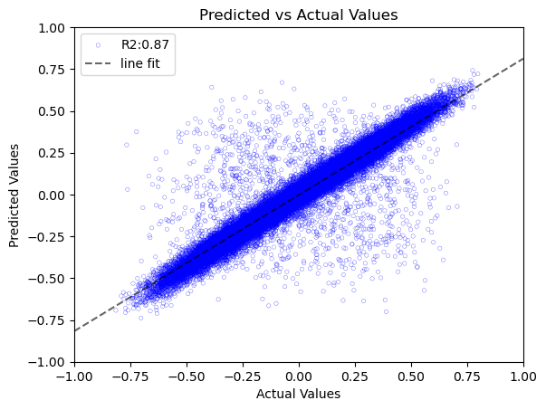

```python
ax=sns.scatterplot(x=y_test12.flatten(),y=y_pred.flatten(),marker='o',edgecolor='b',c='none',s=10,alpha=0.7,label='R2:%.2f'%r2)
ax=plt.plot(xs,ys,c='k',marker='none',linestyle='--',alpha=0.6,label='line fit')
ax=plt.legend()
ax=plt.xlim([-1.0,1.0])
ax=plt.ylim([-1.0,1.0])
ax=plt.margins(0.25)
ax=plt.xlabel('Actual Values')
ax=plt.ylabel('Predicted Values')
ax=plt.title('Predicted vs Actual Values')
```

```python
iconc=0.50 # spin concentration
cread=0    # reading correlation function from input file  otherwise it will be generated randomly
icycles=300  # MC cycles
ianneal=300  # MC input
```

```python
# np.shape(X_test[xvar].reshape((64,-1)))
# ax=imshow(np.flip(X_test[xvar].reshape((64,-1)),0),cmap='gray')

xvar=np.random.randint(0,np.shape(X_test)[0],1)[0]
y_pred = model.predict(X_test)

y_pred[xvar]
# np.shape(X_test[xvar])
#imshow(np.transpose(occ2d),interpolation='nearest',cmap='gray')
```

```
array([ 0.1971551 , -0.00580395,  0.4357482 , -0.1472035 , -0.14021431,
       -0.20304161, -0.29582363,  0.02727254, -0.40242672, -0.15834169,
        0.34120378,  0.20017645,  0.28992668,  0.2872952 ,  0.32804775],
      dtype=float32)
```

```python
def get_metrics_ypred_ytest(xvar):
    corr_test=y_test[xvar]
    corr_pred=y_pred[xvar]
    r2y = r2_score(corr_test, corr_pred)
    msey=mean_squared_error(corr_test, corr_pred)
    maey=mean_absolute_error(corr_test, corr_pred)
    return [r2y,msey,maey]
```

```python
def get_metrics_compare_regens_test_set(xvar,exp=1):
    corr_in=y_test[xvar]
    corr_in=np.r_[1.0,corr_in]
    corr_out=np.loadtxt('./expfiles_%d/corr.out'%exp)
    imdat_0 = X_test[xvar].reshape((64,-1))
    imdat_1 = read_bin('./expfiles_%d/hk0.bin'%exp, npixels=64, offset=1280)

  #  print(corr_in, corr_out.flatten())
  #  print(np.shape(imdat_0))
  #  print(np.shape(imdat_1))
    r2c = r2_score(corr_in.flatten(), corr_out.flatten())
    msec=mean_squared_error(corr_in,corr_out.flatten())
    maec=mean_absolute_error(corr_in,corr_out.flatten())

    r2i=r2_score(imdat_0.flatten(),imdat_1.flatten())
    msei=mean_squared_error(imdat_0.flatten(),imdat_1.flatten())
    maei=mean_absolute_error(imdat_0.flatten(),imdat_1.flatten())
    return [r2c,msec,maec,r2i,msei,maei]

# get_metrics_compare_regens_test_set(xvar,exp=1)
```

```python
# Create a figure and axis for the plot
# Define a function to update the plot
def update_plot_regen(xvar):

    rows,cols =1,3
    fig, axes = plt.subplots(rows, cols, figsize=(6,6))


    imdat = X_test[xvar].reshape((64,-1))
    axes[0].imshow(np.flip(imdat,0),cmap='gray')
    axes[0].axis("off")

    corrin=y_test[xvar]
    fhout=open('corr.in','w')
    fhout.write("1.000000 %.6f %.6f %.6f\n%.6f %.6f %.6f %.6f\n%.6f %.6f %.6f %.6f\n%.6f %.6f %.6f %.6f\n"%(tuple(corrin.flatten())))
    fhout.close()
    calc_diffuse_cfs4(iconc,1,icycles,ianneal,1) # do the regen on the image

    occ3D=get_occ_map('./expfiles_1/ising2D_occ.txt')
    axes[1].imshow(np.transpose(occ3D[:,:,0]),interpolation='nearest',cmap='gray')
    axes[1].axis("off")
    imdat = read_bin('./expfiles_1/hk0.bin', npixels=64, offset=1280)
    axes[2].imshow(np.flip(imdat,0),cmap='gray')
    axes[2].axis("off")

    my_metrics=get_metrics_compare_regens_test_set(xvar)
    fig.suptitle(" metrics(r2, mse, mae)\n corrfunc: %.3f, %.3f, %.3f \n FT_metrics: %.3f, %.3f, %.3f " %(tuple(my_metrics)), fontsize=10,y=0.73)
```

```python
# Create a figure and axis for the plot
# Define a function to update the plot
def update_plot_ypred(xvar):
    rows,cols =1,3
    fig, axes = plt.subplots(rows, cols, figsize=(6,6))

    imdat = X_test[xvar].reshape((64,-1))
    axes[0].imshow(np.flip(imdat,0),cmap='gray')
    axes[0].axis("off")

    corrin=y_pred[xvar]
    fhout=open('corr.in','w')
    fhout.write("1.000000 %.6f %.6f %.6f\n%.6f %.6f %.6f %.6f\n%.6f %.6f %.6f %.6f\n%.6f %.6f %.6f %.6f\n"%(tuple(corrin.flatten())))
    fhout.close()
    calc_diffuse_cfs4(iconc,1,icycles,ianneal,1) # do the regen on the image

    occ3D=get_occ_map('./expfiles_1/ising2D_occ.txt')
    axes[1].imshow(np.transpose(occ3D[:,:,0]),interpolation='nearest',cmap='gray')
    axes[1].axis("off")
    imdat = read_bin('./expfiles_1/hk0.bin', npixels=64, offset=1280)
    axes[2].imshow(np.flip(imdat,0),cmap='gray')
    axes[2].axis("off")

    my_metrics=get_metrics_compare_regens_test_set(xvar)
    my_metrics2=get_metrics_ypred_ytest(xvar)
    fig.suptitle("metrics(r2, mse, mae)\n corrfunc: %.3f, %.3f, %.3f \n FT_metrics: %.3f, %.3f, %.3f" %tuple(my_metrics) + "\n corrfunc test vs. pred: %.3f, %.3f, %.3f" %(my_metrics2[0], my_metrics2[1], my_metrics2[2]), fontsize=10, y=0.73)
```

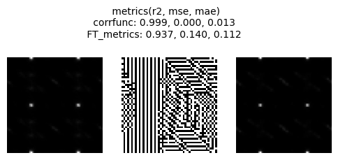

```python
xvar=np.random.randint(0,np.shape(X_test)[0],1)[0]
update_plot_regen(xvar)
# get_metrics_compare_regens_test_set(xvar)
```

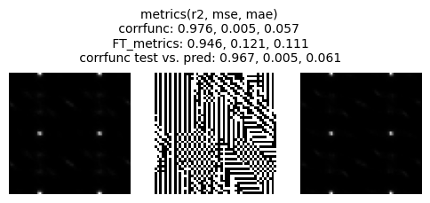

```python
update_plot_ypred(xvar)
```

```python
#### might have to block average these metrics to get a better variance
#### wonder what happens when i put other types of images into the model

print(" metrics(r2, mse, mae)\n corrfunc test vs. pred: %.3f, %.3f, %.3f \n " %(tuple(get_metrics_ypred_ytest(xvar))))
```

[output not shown]